# CHL Calcs & Cleanup: 2010-2018 [IV]

## [13] SBCI

- Total Records :: 186
- Number of CHL-methods :: 1
  - Methods:: 10200
- Records by PARAM

|  | .$MethodID2 10200 |
| --- | --- |
| .$PARAM.X |  |
| CHLA.aa | 62 |
| CHLA.tot | 62 |
| PHEO | 62 |
| Sum | 186 |

- Sample Date Range :: [2013-10-30] to [2014-09-17]
- PARAMs over time

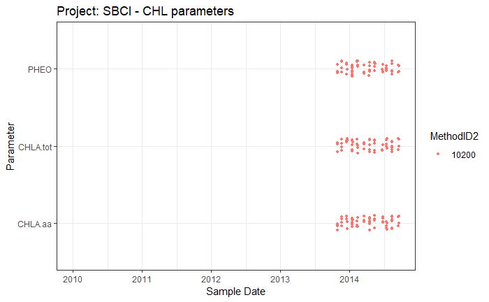

```r
CHL1016_04 %>% filter(PROJ_grp == "SBCI") %>%
  ggplot(.,
         aes(y=x_SDate, x=factor(PARAM.X),col=MethodID2)) + theme_bw() +
  geom_point(na.rm=T,
             position=position_jitter(width=0.1), size=1) +
  xlab("Parameter") + ylab("Sample Date") +
  scale_y_date(date_labels ="%Y",
               date_breaks="1 year",
               limits=c(as.Date("2010-01-01"), NA)) +
  coord_flip() +
  ggtitle("Project: SBCI - CHL parameters")
```

**Convert “CHLA.X” to “CHLA.tot” for analyses**  
**Ignore “CHLB” and “PHEO”**

- Reporting Limits over time (*ignoring PHEO*)

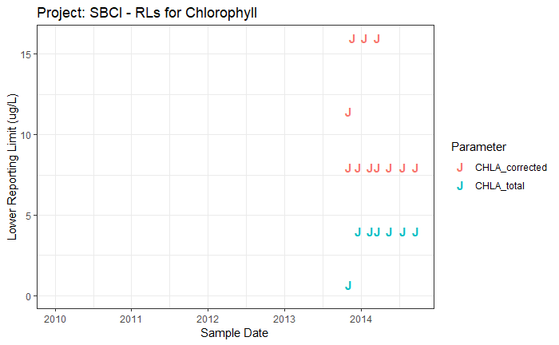

```r
CHL1016_04 %>% filter(PROJ_grp == "SBCI" & PARAM.X != "PHEO" & PARAM.X != "CHLB") %>%
  mutate(PARAM.X = recode(.$PARAM.X,
                          "CHLA.X" = "CHLA_total",
                          "CHLA.tot" = "CHLA_total",
                          "CHLA.aa" = "CHLA_corrected")) %>%
  ggplot(.,
         aes(x=x_SDate, y=LRL_c, col=PARAM.X), na.rm=T) + theme_bw() +
  geom_text(na.rm=T, fontface="bold",
            check_overlap = T,label="J") +
  scale_x_date(date_labels="%Y",date_breaks = "1 year",
               limits=c(as.Date("2010-01-01"), NA)) +
  scale_y_continuous(limits=c(0, NA)) +
  labs(x="Sample Date", y="Lower Reporting Limit (ug/L)", col="Parameter") +
  ggtitle("Project: SBCI - RLs for Chlorophyll")
```

- Records where neither an RVal_conc or RL exist :: 1
- Records where CHL filtration volume is missing :: 2
- Distribution of reporting limits

```r
CHL1016_04 %>% filter(PROJ_grp == "SBCI" & PARAM.X != "PHEO" & PARAM.X != "CHLB") %>%
  {addmargins(table(.$PARAM.X, .$Non_Detect, useNA="ifany", deparse.level = 2))}
```

```
          .$Non_Detect
.$PARAM.X    U <NA> Sum
  CHLA.aa   57    5  62
  CHLA.tot  41   21  62
  Sum       98   26 124
```

- Many non-detects here

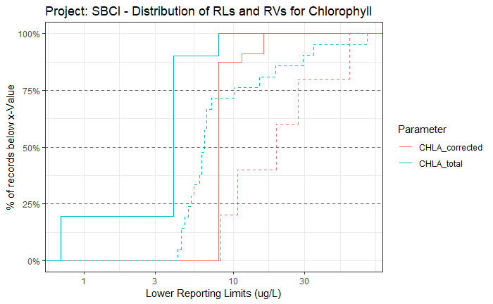

```r
CHL1016_04 %>% filter(PROJ_grp == "SBCI" & PARAM.X != "PHEO" & PARAM.X != "CHLB") %>%
  mutate(PARAM.X = recode(.$PARAM.X,
                          "CHLA.X" = "CHLA_total",
                          "CHLA.tot" = "CHLA_total",
                          "CHLA.aa" = "CHLA_corrected")) %>%
  ggplot(.) + theme_bw() +
  stat_ecdf(aes(x=LRL_c, col=PARAM.X), na.rm=T, lty=1) +
  stat_ecdf(aes(x=x_RVal.conc, col=PARAM.X), na.rm=T, lty=2) +
  labs(x="Lower Reporting Limits (ug/L)", y="% of records below x-Value",
       col="Parameter") +
  scale_x_continuous(trans="log10") +
  scale_y_continuous(labels=percent) +
  geom_hline(yintercept = c(0.25,0.5,0.75), lty=2, color="gray40") +
  ggtitle("Project: SBCI - Distribution of RLs and RVs for Chlorophyll")
```

## [14] TMDLLAKES

- Total Records :: 774
- Number of CHL-methods :: 1
  - Methods:: 10200
- Records by PARAM

|  | .$MethodID2 10200 |
| --- | --- |
| .$PARAM.X |  |
| CHLA.aa | 137 |
| CHLA.tot | 128 |
| CHLA.X | 381 |
| PHEO | 128 |
| Sum | 774 |

- Sample Date Range :: [2010-06-02] to [2015-05-20]
- PARAMs over time

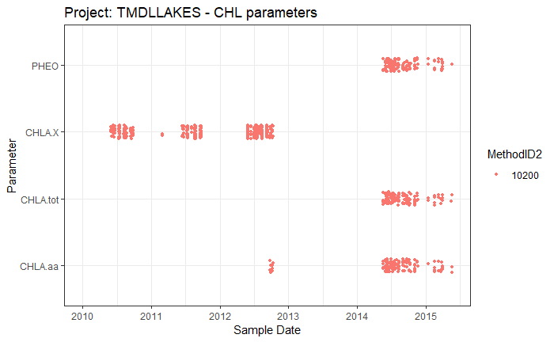

```r
CHL1016_04 %>% filter(PROJ_grp == "TMDLLAKES") %>%
  ggplot(.,
         aes(y=x_SDate, x=factor(PARAM.X),col=MethodID2)) + theme_bw() +
  geom_point(na.rm=T,
             position=position_jitter(width=0.1), size=1) +
  xlab("Parameter") + ylab("Sample Date") +
  scale_y_date(date_labels ="%Y",
               date_breaks="1 year",
               limits=c(as.Date("2010-01-01"), NA)) +
  coord_flip() +
  ggtitle("Project: TMDLLAKES - CHL parameters")
```

**Convert “CHLA.X” to “CHLA.tot” for analyses**  
**Ignore “CHLB” and “PHEO”**

- Reporting Limits over time (*ignoring PHEO*)

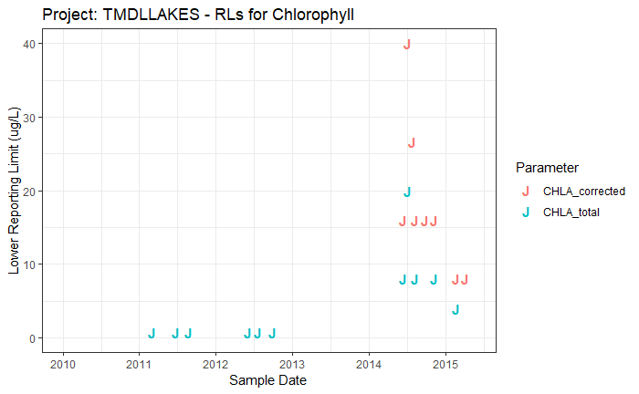

```r
CHL1016_04 %>% filter(PROJ_grp == "TMDLLAKES" & PARAM.X != "PHEO" & PARAM.X != "CHLB") %>%
  mutate(PARAM.X = recode(.$PARAM.X,
                          "CHLA.X" = "CHLA_total",
                          "CHLA.tot" = "CHLA_total",
                          "CHLA.aa" = "CHLA_corrected")) %>%
  ggplot(.,
         aes(x=x_SDate, y=LRL_c, col=PARAM.X), na.rm=T) + theme_bw() +
  geom_text(na.rm=T, fontface="bold",
            check_overlap = T,label="J") +
  scale_x_date(date_labels="%Y",date_breaks = "1 year",
               limits=c(as.Date("2010-01-01"), NA)) +
  scale_y_continuous(limits=c(0, NA)) +
  labs(x="Sample Date", y="Lower Reporting Limit (ug/L)", col="Parameter") +
  ggtitle("Project: TMDLLAKES - RLs for Chlorophyll")
```

- Records where neither an RVal_conc or RL exist :: 32
- Records where CHL filtration volume is missing :: 144
- Distribution of reporting limits

```r
CHL1016_04 %>% filter(PROJ_grp == "TMDLLAKES" & PARAM.X != "PHEO" & PARAM.X != "CHLB") %>%
  {addmargins(table(.$PARAM.X, .$Non_Detect, useNA="ifany", deparse.level = 2))}
```

```
          .$Non_Detect
.$PARAM.X    U <NA> Sum
  CHLA.aa  106   31 137
  CHLA.tot  70   58 128
  CHLA.X    96  285 381
  Sum      272  374 646
```

- Many non-detects here

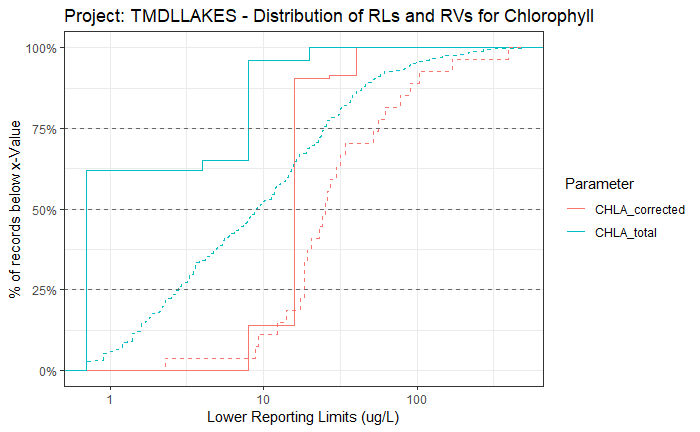

```r
CHL1016_04 %>% filter(PROJ_grp == "TMDLLAKES" & PARAM.X != "PHEO" & PARAM.X != "CHLB") %>%
  mutate(PARAM.X = recode(.$PARAM.X,
                          "CHLA.X" = "CHLA_total",
                          "CHLA.tot" = "CHLA_total",
                          "CHLA.aa" = "CHLA_corrected")) %>%
  ggplot(.) + theme_bw() +
  stat_ecdf(aes(x=LRL_c, col=PARAM.X), na.rm=T, lty=1) +
  stat_ecdf(aes(x=x_RVal.conc, col=PARAM.X), na.rm=T, lty=2) +
  labs(x="Lower Reporting Limits (ug/L)", y="% of records below x-Value",
       col="Parameter") +
  scale_x_continuous(trans="log10") +
  scale_y_continuous(labels=percent) +
  geom_hline(yintercept = c(0.25,0.5,0.75), lty=2, color="gray40") +
  ggtitle("Project: TMDLLAKES - Distribution of RLs and RVs for Chlorophyll")
```

## [15] UBI

- Only 4 records
- **No filtration Volumes found**
- If data are needed, field-measures must be completed by DPM

## [16] UCASE

- Total Records :: 2094
- Number of CHL-methods :: 2
  - Methods:: 10200, 10300
- Records by PARAM

|  | .$MethodID2 10200 | .$MethodID2 10300 |
| --- | --- | --- |
| .$PARAM.X |  |  |
| CHLA.aa | 522 | 0 |
| CHLA.tot | 548 | 0 |
| CHLA.X | 113 | 0 |
| PERI | 0 | 391 |
| PHEO | 520 | 0 |
| Sum | 1703 | 391 |

- Sample Date Range :: [2010-04-13] to [2016-09-22]
- PARAMs over time

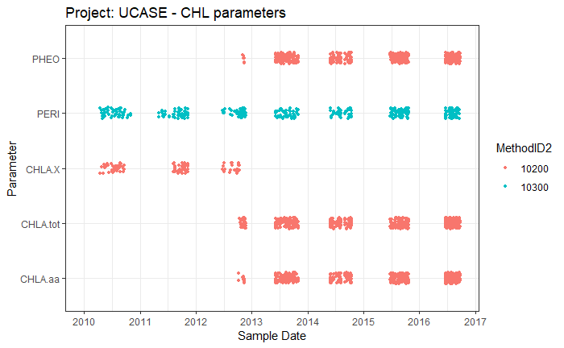

```r
CHL1016_04 %>% filter(PROJ_grp == "UCASE") %>%
  ggplot(.,
         aes(y=x_SDate, x=factor(PARAM.X),col=MethodID2)) + theme_bw() +
  geom_point(na.rm=T,
             position=position_jitter(width=0.1), size=1) +
  xlab("Parameter") + ylab("Sample Date") +
  scale_y_date(date_labels ="%Y",
               date_breaks="1 year",
               limits=c(as.Date("2010-01-01"), NA)) +
  coord_flip() +
  ggtitle("Project: UCASE - CHL parameters")
```

**Convert “CHLA.X” to “CHLA.tot” for analyses**  
**Ignore “CHLB” and “PHEO”**

**Note** :: `PERI` refers to AFDM from benthic samples. *There will also be some benthic CHL samples here as well !!* These need to be examined for Sample.Matrix and Result.Unit differences to discriminate b/w water column vs. benthic samples

- Reporting Limits over time (*ignoring PHEO and PERI*)

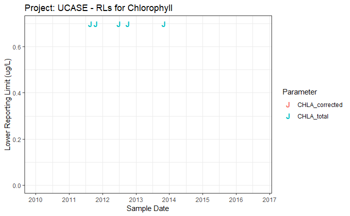

```r
CHL1016_04 %>%
  filter(PROJ_grp == "UCASE" &
           PARAM.X != "PHEO" &
           PARAM.X != "CHLB" & PARAM.X != "PERI") %>%
  mutate(PARAM.X = recode(.$PARAM.X,
                          "CHLA.X" = "CHLA_total",
                          "CHLA.tot" = "CHLA_total",
                          "CHLA.aa" = "CHLA_corrected")) %>%
  ggplot(.,
         aes(x=x_SDate, y=LRL_c, col=PARAM.X), na.rm=T) + theme_bw() +
  geom_text(na.rm=T, fontface="bold",
            check_overlap = T,label="J") +
  scale_x_date(date_labels="%Y",date_breaks = "1 year",
               limits=c(as.Date("2010-01-01"), NA)) +
  scale_y_continuous(limits=c(0, NA)) +
  labs(x="Sample Date", y="Lower Reporting Limit (ug/L)", col="Parameter") +
  ggtitle("Project: UCASE - RLs for Chlorophyll")
```

- Records where neither an RVal_conc or RL exist :: 1143
- Records where CHL filtration volume is missing :: 220
- Distribution of reporting limits

```r
CHL1016_04 %>%
  filter(PROJ_grp == "UCASE" & PARAM.X != "PHEO" & PARAM.X != "CHLB" & PARAM.X != "PERI") %>%
  {addmargins(table(.$PARAM.X, .$Non_Detect, useNA="ifany", deparse.level = 2))}
```

```
          .$Non_Detect
.$PARAM.X     U <NA>  Sum
  CHLA.aa   284  238  522
  CHLA.tot  195  353  548
  CHLA.X      9  104  113
  Sum       488  695 1183
```

- Many non-detects here

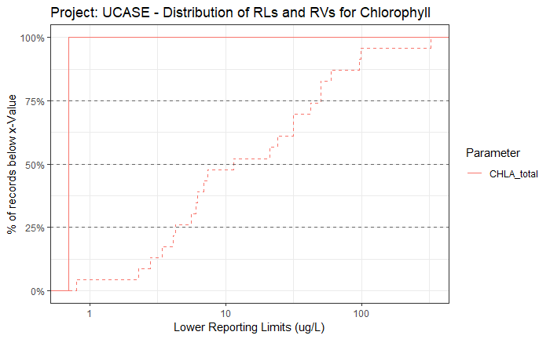

```r
CHL1016_04 %>%
  filter(PROJ_grp == "UCASE" & PARAM.X != "PHEO" & PARAM.X != "CHLB" & PARAM.X != "PERI") %>%
  mutate(PARAM.X = recode(.$PARAM.X,
                          "CHLA.X" = "CHLA_total",
                          "CHLA.tot" = "CHLA_total",
                          "CHLA.aa" = "CHLA_corrected")) %>%
  ggplot(.) + theme_bw() +
  stat_ecdf(aes(x=LRL_c, col=PARAM.X), na.rm=T, lty=1) +
  stat_ecdf(aes(x=x_RVal.conc, col=PARAM.X), na.rm=T, lty=2) +
  labs(x="Lower Reporting Limits (ug/L)", y="% of records below x-Value",
       col="Parameter") +
  scale_x_continuous(trans="log10") +
  scale_y_continuous(labels=percent) +
  geom_hline(yintercept = c(0.25,0.5,0.75), lty=2, color="gray40") +
  ggtitle("Project: UCASE - Distribution of RLs and RVs for Chlorophyll")
```

> **Action**: Discriminate water-column vs. benthic matrices

> *Come back to this project a little later*

## [17] Unknown

- Total Records :: 106
- Number of CHL-methods :: 2
  - Methods:: 10200, 10300
- Records by PARAM

|  | .$MethodID2 10200 | .$MethodID2 10300 |
| --- | --- | --- |
| .$PARAM.X |  |  |
| CHLA.aa | 22 | 0 |
| CHLA.tot | 22 | 0 |
| CHLA.X | 34 | 0 |
| PERI | 0 | 6 |
| PHEO | 22 | 0 |
| Sum | 100 | 6 |

- Sample Date Range :: [2010-11-02] to [2016-09-22]
- PARAMs over time

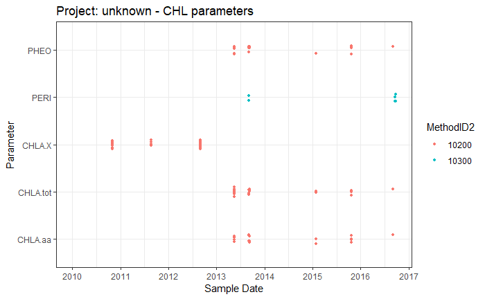

```r
CHL1016_04 %>% filter(PROJ_grp == "unknown") %>%
  ggplot(.,
         aes(y=x_SDate, x=factor(PARAM.X),col=MethodID2)) + theme_bw() +
  geom_point(na.rm=T,
             position=position_jitter(width=0.1), size=1) +
  xlab("Parameter") + ylab("Sample Date") +
  scale_y_date(date_labels ="%Y",
               date_breaks="1 year",
               limits=c(as.Date("2010-01-01"), NA)) +
  coord_flip() +
  ggtitle("Project: unknown - CHL parameters")
```

> **This is a mixed bag of projects, and these will need to be corrected once the main projects are finished…**

## [18] USFS

- Total Records :: 47
- Number of CHL-methods :: 1
  - Methods:: 10200
- Records by PARAM

|  | .$MethodID2 10200 |
| --- | --- |
| .$PARAM.X |  |
| CHLA.X | 47 |
| Sum | 47 |

- Sample Date Range :: [2010-08-16] to [2010-11-05]

> **These samples are all from 2010. No filtration volume required**
- PARAMs over time

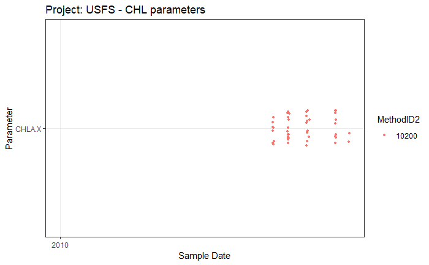

```r
CHL1016_04 %>% filter(PROJ_grp == "USFS") %>%
  ggplot(.,
         aes(y=x_SDate, x=factor(PARAM.X),col=MethodID2)) + theme_bw() +
  geom_point(na.rm=T,
             position=position_jitter(width=0.1), size=1) +
  xlab("Parameter") + ylab("Sample Date") +
  scale_y_date(date_labels ="%Y",
               date_breaks="1 year",
               limits=c(as.Date("2010-01-01"), NA)) +
  coord_flip() +
  ggtitle("Project: USFS - CHL parameters")
```

- Records where neither an RVal_conc or RL exist :: 0
- Records where CHL filtration volume is missing :: 47

> These data can be used to compare frequency of non-detects, if needed

## [19] UtahLk

- Total Records :: 42
- Number of CHL-methods :: 1
  - Methods:: 10200
- Records by PARAM

|  | .$MethodID2 10200 |
| --- | --- |
| .$PARAM.X |  |
| CHLA.aa | 5 |
| CHLA.tot | 5 |
| CHLA.X | 27 |
| PHEO | 5 |
| Sum | 42 |

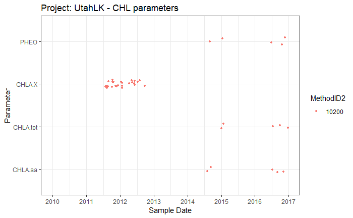

```r
CHL1016_04 %>% filter(PROJ_grp == "UtahLK") %>%
  ggplot(.,
         aes(y=x_SDate, x=factor(PARAM.X),col=MethodID2)) + theme_bw() +
  geom_point(na.rm=T,
             position=position_jitter(width=0.1), size=1) +
  xlab("Parameter") + ylab("Sample Date") +
  scale_y_date(date_labels ="%Y",
               date_breaks="1 year",
               limits=c(as.Date("2010-01-01"), NA)) +
  coord_flip() +
  ggtitle("Project: UtahLK - CHL parameters")
```

**Convert “CHLA.X” to “CHLA.tot” for analyses**  
**Ignore “CHLB” and “PHEO”**

- Reporting Limits over time (*ignoring PHEO*)

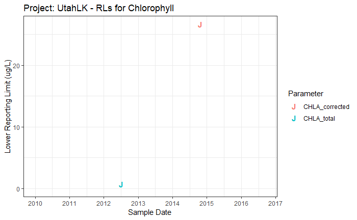

```r
CHL1016_04 %>% filter(PROJ_grp == "UtahLK" & PARAM.X != "PHEO" & PARAM.X != "CHLB") %>%
  mutate(PARAM.X = recode(.$PARAM.X,
                          "CHLA.X" = "CHLA_total",
                          "CHLA.tot" = "CHLA_total",
                          "CHLA.aa" = "CHLA_corrected")) %>%
  ggplot(.,
         aes(x=x_SDate, y=LRL_c, col=PARAM.X), na.rm=T) + theme_bw() +
  geom_text(na.rm=T, fontface="bold",
            check_overlap = T,label="J") +
  scale_x_date(date_labels="%Y",date_breaks = "1 year",
               limits=c(as.Date("2010-01-01"), NA)) +
  scale_y_continuous(limits=c(0, NA)) +
  labs(x="Sample Date", y="Lower Reporting Limit (ug/L)", col="Parameter") +
  ggtitle("Project: UtahLK - RLs for Chlorophyll")
```

- Records where neither an RVal_conc or RL exist :: 6
- Records where CHL filtration volume is missing :: 7

> These look to be some early UTLK records sampled prior to Utah Lake main project, and/or from site(s) that are no longer key-monitoring-sites [??]
- Non-Detects

```r
CHL1016_04 %>% filter(PROJ_grp == "UtahLK" & PARAM.X != "PHEO" & PARAM.X != "CHLB") %>%
  {addmargins(table(.$PARAM.X, .$Non_Detect, useNA="ifany", deparse.level = 2))}
```

```
          .$Non_Detect
.$PARAM.X   U <NA> Sum
  CHLA.aa   1    4   5
  CHLA.tot  0    5   5
  CHLA.X    2   25  27
  Sum       3   34  37
```

> **Action**:
1. ID sites
2. find filtration.volumes
3. make calculations

## [20] WINTERLAKES

- Total Records :: 28
- Number of CHL-methods :: 1
  - Methods:: 10200
- Records by PARAM

|  | .$MethodID2 10200 |
| --- | --- |
| .$PARAM.X |  |
| CHLA.X | 28 |
| Sum | 28 |

- Sample Date Range :: [2010-02-02] to [2012-02-28]
- PARAMs over time

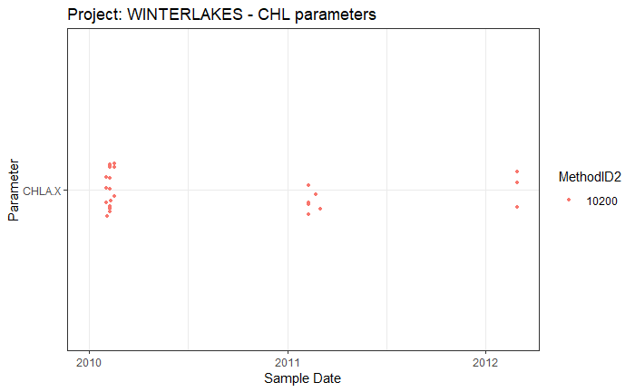

```r
CHL1016_04 %>% filter(PROJ_grp == "WINTERLAKES") %>%
  ggplot(.,
         aes(y=x_SDate, x=factor(PARAM.X),col=MethodID2)) + theme_bw() +
  geom_point(na.rm=T,
             position=position_jitter(width=0.1), size=1) +
  xlab("Parameter") + ylab("Sample Date") +
  scale_y_date(date_labels ="%Y",
               date_breaks="1 year",
               limits=c(as.Date("2010-01-01"), NA)) +
  coord_flip() +
  ggtitle("Project: WINTERLAKES - CHL parameters")
```

- A few older lakes samples where filt.vol is not required

## [21] WLA

- Total Records :: 326
- Number of CHL-methods :: 1
  - Methods:: 10200
- Records by PARAM

|  | .$MethodID2 10200 |
| --- | --- |
| .$PARAM.X |  |
| CHLA.aa | 85 |
| CHLA.tot | 85 |
| CHLA.X | 71 |
| PHEO | 85 |
| Sum | 326 |

- Sample Date Range :: [2011-09-15] to [2015-07-28]
- PARAMs over time

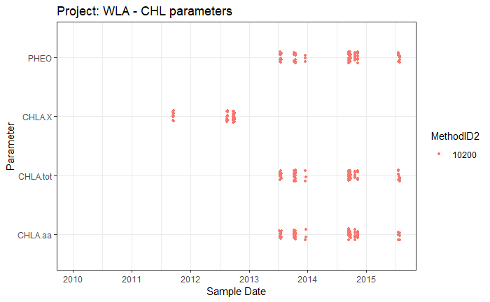

```r
CHL1016_04 %>% filter(PROJ_grp == "WLA") %>%
  ggplot(.,
         aes(y=x_SDate, x=factor(PARAM.X),col=MethodID2)) + theme_bw() +
  geom_point(na.rm=T,
             position=position_jitter(width=0.1), size=1) +
  xlab("Parameter") + ylab("Sample Date") +
  scale_y_date(date_labels ="%Y",
               date_breaks="1 year",
               limits=c(as.Date("2010-01-01"), NA)) +
  coord_flip() +
  ggtitle("Project: WLA - CHL parameters")
```

**Convert “CHLA.X” to “CHLA.tot” for analyses**  
**Ignore “CHLB” and “PHEO”**

- Reporting Limits over time (*ignoring PHEO*)

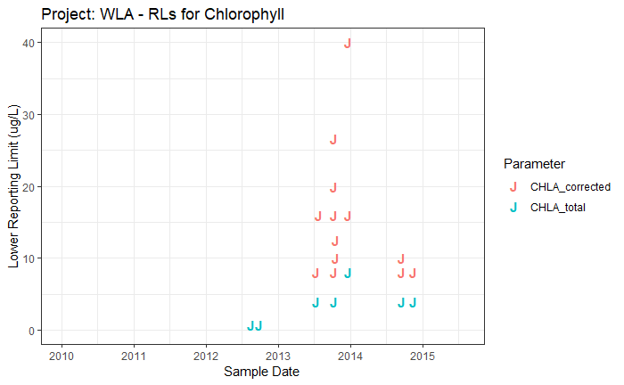

```r
CHL1016_04 %>% filter(PROJ_grp == "WLA" & PARAM.X != "PHEO" & PARAM.X != "CHLB") %>%
  mutate(PARAM.X = recode(.$PARAM.X,
                          "CHLA.X" = "CHLA_total",
                          "CHLA.tot" = "CHLA_total",
                          "CHLA.aa" = "CHLA_corrected")) %>%
  ggplot(.,
         aes(x=x_SDate, y=LRL_c, col=PARAM.X), na.rm=T) + theme_bw() +
  geom_text(na.rm=T, fontface="bold",
            check_overlap = T,label="J") +
  scale_x_date(date_labels="%Y",date_breaks = "1 year",
               limits=c(as.Date("2010-01-01"), NA)) +
  scale_y_continuous(limits=c(0, NA)) +
  labs(x="Sample Date", y="Lower Reporting Limit (ug/L)", col="Parameter") +
  ggtitle("Project: WLA - RLs for Chlorophyll")
```

- Records where neither an RVal_conc or RL exist :: 16
- Records where CHL filtration volume is missing :: 27
- Non-Detects

```r
CHL1016_04 %>% filter(PROJ_grp == "WLA" & PARAM.X != "PHEO" & PARAM.X != "CHLB") %>%
  {addmargins(table(.$PARAM.X, .$Non_Detect, useNA="ifany", deparse.level = 2))}
```

```
          .$Non_Detect
.$PARAM.X    U <NA> Sum
  CHLA.aa   76    9  85
  CHLA.tot  50   35  85
  CHLA.X    18   53  71
  Sum      144   97 241
```

- Many non-detects here
- Distribution of reporting limits

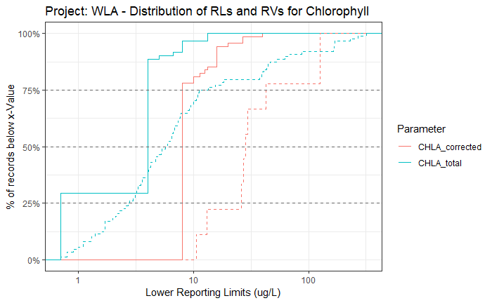

```r
CHL1016_04 %>% filter(PROJ_grp == "WLA" & PARAM.X != "PHEO" & PARAM.X != "CHLB") %>%
  mutate(PARAM.X = recode(.$PARAM.X,
                          "CHLA.X" = "CHLA_total",
                          "CHLA.tot" = "CHLA_total",
                          "CHLA.aa" = "CHLA_corrected")) %>%
  ggplot(.) + theme_bw() +
  stat_ecdf(aes(x=LRL_c, col=PARAM.X), na.rm=T, lty=1) +
  stat_ecdf(aes(x=x_RVal.conc, col=PARAM.X), na.rm=T, lty=2) +
  labs(x="Lower Reporting Limits (ug/L)", y="% of records below x-Value",
       col="Parameter") +
  scale_x_continuous(trans="log10") +
  scale_y_continuous(labels=percent) +
  geom_hline(yintercept = c(0.25,0.5,0.75), lty=2, color="gray40") +
  ggtitle("Project: WLA - Distribution of RLs and RVs for Chlorophyll")
```

- Find volumes for samples from 2015

## [22] WRI

- Total Records :: 720
- Number of CHL-methods :: 1
  - Methods:: 10200
- Records by PARAM

|  | .$MethodID2 10200 |
| --- | --- |
| .$PARAM.X |  |
| CHLA.aa | 240 |
| CHLA.tot | 240 |
| PHEO | 240 |
| Sum | 720 |

- Sample Date Range :: [2016-05-16] to [2016-09-21]
- PARAMs over time

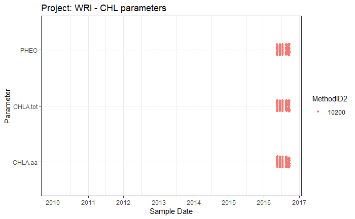

```r
CHL1016_04 %>% filter(PROJ_grp == "WRI") %>%
  ggplot(.,
         aes(y=x_SDate, x=factor(PARAM.X),col=MethodID2)) + theme_bw() +
  geom_point(na.rm=T,
             position=position_jitter(width=0.1), size=1) +
  xlab("Parameter") + ylab("Sample Date") +
  scale_y_date(date_labels ="%Y",
               date_breaks="1 year",
               limits=c(as.Date("2010-01-01"), NA)) +
  coord_flip() +
  ggtitle("Project: WRI - CHL parameters")
```

**Convert “CHLA.X” to “CHLA.tot” for analyses**  
**Ignore “CHLB” and “PHEO”**

- Reporting Limits over time (*ignoring PHEO*)

[figure not shown]

```r
CHL1016_04 %>% filter(PROJ_grp == "WRI" & PARAM.X != "PHEO" & PARAM.X != "CHLB") %>%
  mutate(PARAM.X = recode(.$PARAM.X,
                          "CHLA.X" = "CHLA_total",
                          "CHLA.tot" = "CHLA_total",
                          "CHLA.aa" = "CHLA_corrected")) %>%
  ggplot(.,
         aes(x=x_SDate, y=LRL_c, col=PARAM.X), na.rm=T) + theme_bw() +
  geom_text(na.rm=T, fontface="bold",
            check_overlap = T,label="J") +
  scale_x_date(date_labels="%Y",date_breaks = "1 year",
               limits=c(as.Date("2010-01-01"), NA)) +
  scale_y_continuous(limits=c(0, NA)) +
  labs(x="Sample Date", y="Lower Reporting Limit (ug/L)", col="Parameter") +
  ggtitle("Project: WRI - RLs for Chlorophyll")
```

- Records where neither an RVal_conc or RL exist :: 480
- Records where CHL filtration volume is missing :: 480

> **Action**: Need all Filtration Volumes !!
- Non-Detects

```r
CHL1016_04 %>% filter(PROJ_grp == "WRI" & PARAM.X != "PHEO" & PARAM.X != "CHLB") %>%
  {addmargins(table(.$PARAM.X, .$Non_Detect, useNA="ifany", deparse.level = 2))}
```

```
          .$Non_Detect
.$PARAM.X    U <NA> Sum
  CHLA.aa  169   71 240
  CHLA.tot 100  140 240
  Sum      269  211 480
```

- Many non-detects here
- Distribution of reporting limits

[figure not shown]

```r
CHL1016_04 %>% filter(PROJ_grp == "WRI" & PARAM.X != "PHEO" & PARAM.X != "CHLB") %>%
  mutate(PARAM.X = recode(.$PARAM.X,
                          "CHLA.X" = "CHLA_total",
                          "CHLA.tot" = "CHLA_total",
                          "CHLA.aa" = "CHLA_corrected")) %>%
  ggplot(.) + theme_bw() +
  stat_ecdf(aes(x=LRL_c, col=PARAM.X), na.rm=T, lty=1) +
  stat_ecdf(aes(x=x_RVal.conc, col=PARAM.X), na.rm=T, lty=2) +
  labs(x="Lower Reporting Limits (ug/L)", y="% of records below x-Value",
       col="Parameter") +
  scale_x_continuous(trans="log10") +
  scale_y_continuous(labels=percent) +
  geom_hline(yintercept = c(0.25,0.5,0.75), lty=2, color="gray40") +
  ggtitle("Project: WRI - Distribution of RLs and RVs for Chlorophyll")
```

## [23] WSpur

- Connect w/ Suzan re: these data and data-integration with all other
- Total Records :: 2195
- Number of CHL-methods :: 2
  - Methods:: 10200, 10300
- Records by PARAM

|  | .$MethodID2 10200 | .$MethodID2 10300 |
| --- | --- | --- |
| .$PARAM.X |  |  |
| CHLA.aa | 312 | 0 |
| CHLA.tot | 423 | 0 |
| CHLA.X | 869 | 0 |
| PERI | 0 | 279 |
| PHEO | 312 | 0 |
| Sum | 1916 | 279 |

- Sample Date Range :: [2010-08-02] to [2016-07-14]
- PARAMs over time

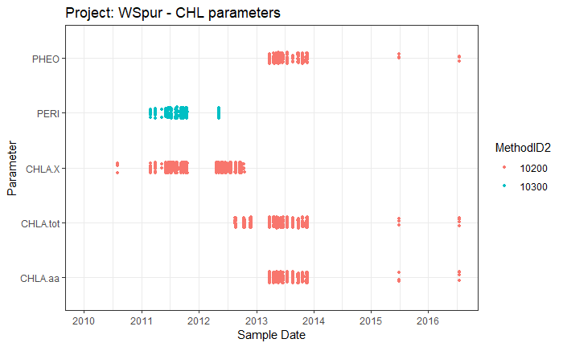

```r
CHL1016_04 %>% filter(PROJ_grp == "WSpur") %>%
  ggplot(.,
         aes(y=x_SDate, x=factor(PARAM.X),col=MethodID2)) + theme_bw() +
  geom_point(na.rm=T,
             position=position_jitter(width=0.1), size=1) +
  xlab("Parameter") + ylab("Sample Date") +
  scale_y_date(date_labels ="%Y",
               date_breaks="1 year",
               limits=c(as.Date("2010-01-01"), NA)) +
  coord_flip() +
  ggtitle("Project: WSpur - CHL parameters")
```

**Convert “CHLA.X” to “CHLA.tot” for analyses**  
**Ignore “CHLB” and “PHEO”**

- Reporting Limits over time (*ignoring PHEO*)

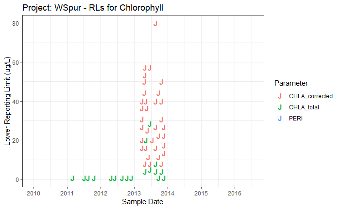

```r
CHL1016_04 %>% filter(PROJ_grp == "WSpur" & PARAM.X != "PHEO" & PARAM.X != "CHLB") %>%
  mutate(PARAM.X = recode(.$PARAM.X,
                          "CHLA.X" = "CHLA_total",
                          "CHLA.tot" = "CHLA_total",
                          "CHLA.aa" = "CHLA_corrected")) %>%
  ggplot(.,
         aes(x=x_SDate, y=LRL_c, col=PARAM.X), na.rm=T) + theme_bw() +
  geom_text(na.rm=T, fontface="bold",
            check_overlap = T,label="J") +
  scale_x_date(date_labels="%Y",date_breaks = "1 year",
               limits=c(as.Date("2010-01-01"), NA)) +
  scale_y_continuous(limits=c(0, NA)) +
  labs(x="Sample Date", y="Lower Reporting Limit (ug/L)", col="Parameter") +
  ggtitle("Project: WSpur - RLs for Chlorophyll")
```

- Records where neither an RVal_conc or RL exist :: 489
- Records where CHL filtration volume is missing :: 409

> **Action**: Need all Filtration Volumes !!
- Non-Detects

```r
CHL1016_04 %>% filter(PROJ_grp == "WSpur" & PARAM.X != "PHEO" & PARAM.X != "CHLB") %>%
  {addmargins(table(.$PARAM.X, .$Non_Detect, useNA="ifany", deparse.level = 2))}
```

```
          .$Non_Detect
.$PARAM.X     U <NA>  Sum
  CHLA.aa   245   67  312
  CHLA.tot  188  235  423
  CHLA.X    143  726  869
  PERI        0  279  279
  Sum       576 1307 1883
```

- Many non-detects here
- Distribution of reporting limits

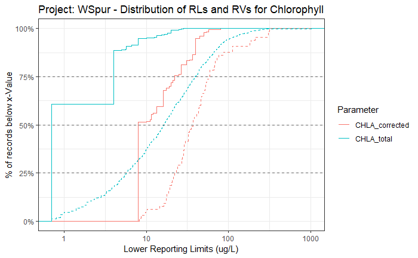

```r
CHL1016_04 %>% filter(PROJ_grp == "WSpur" & PARAM.X != "PHEO" & PARAM.X != "CHLB") %>%
  mutate(PARAM.X = recode(.$PARAM.X,
                          "CHLA.X" = "CHLA_total",
                          "CHLA.tot" = "CHLA_total",
                          "CHLA.aa" = "CHLA_corrected")) %>%
  ggplot(.) + theme_bw() +
  stat_ecdf(aes(x=LRL_c, col=PARAM.X), na.rm=T, lty=1) +
  stat_ecdf(aes(x=x_RVal.conc, col=PARAM.X), na.rm=T, lty=2) +
  labs(x="Lower Reporting Limits (ug/L)", y="% of records below x-Value",
       col="Parameter") +
  scale_x_continuous(trans="log10") +
  scale_y_continuous(labels=percent) +
  geom_hline(yintercept = c(0.25,0.5,0.75), lty=2, color="gray40") +
  ggtitle("Project: WSpur - Distribution of RLs and RVs for Chlorophyll")
```

- Quite a few benthic records…
- Need most filtration volumes from 2015 (and others)

## [24] WWTP

- Total Records :: 1067
- Number of CHL-methods :: 2
  - Methods:: 10200, 10300
- Records by PARAM

|  | .$MethodID2 10200 | .$MethodID2 10300 |
| --- | --- | --- |
| .$PARAM.X |  |  |
| CHLA.tot | 10 | 0 |
| CHLA.X | 1034 | 0 |
| PERI | 0 | 23 |
| Sum | 1044 | 23 |

- Sample Date Range :: [2010-07-14] to [2012-11-02]
- PARAMs over time

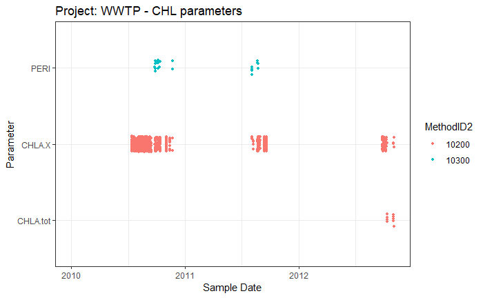

```r
CHL1016_04 %>% filter(PROJ_grp == "WWTP") %>%
  ggplot(.,
         aes(y=x_SDate, x=factor(PARAM.X),col=MethodID2)) + theme_bw() +
  geom_point(na.rm=T,
             position=position_jitter(width=0.1), size=1) +
  xlab("Parameter") + ylab("Sample Date") +
  scale_y_date(date_labels ="%Y",
               date_breaks="1 year",
               limits=c(as.Date("2010-01-01"), NA)) +
  coord_flip() +
  ggtitle("Project: WWTP - CHL parameters")
```

**Convert “CHLA.X” to “CHLA.tot” for analyses**  
**Ignore “CHLB” and “PHEO”**

- Reporting Limits over time (*ignoring PHEO*)

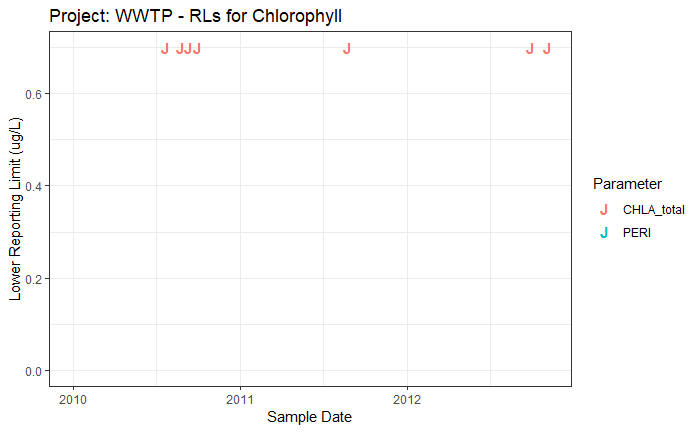

```r
CHL1016_04 %>% filter(PROJ_grp == "WWTP" & PARAM.X != "PHEO" & PARAM.X != "CHLB") %>%
  mutate(PARAM.X = recode(.$PARAM.X,
                          "CHLA.X" = "CHLA_total",
                          "CHLA.tot" = "CHLA_total",
                          "CHLA.aa" = "CHLA_corrected")) %>%
  ggplot(.,
         aes(x=x_SDate, y=LRL_c, col=PARAM.X), na.rm=T) + theme_bw() +
  geom_text(na.rm=T, fontface="bold",
            check_overlap = T,label="J") +
  scale_x_date(date_labels="%Y",date_breaks = "1 year",
               limits=c(as.Date("2010-01-01"), NA)) +
  scale_y_continuous(limits=c(0, NA)) +
  labs(x="Sample Date", y="Lower Reporting Limit (ug/L)", col="Parameter") +
  ggtitle("Project: WWTP - RLs for Chlorophyll")
```

- Records where neither an RVal_conc or RL exist :: 554
- Records where CHL filtration volume is missing :: 928
- Look at MATRIX.X for WC vs. Benthic samples

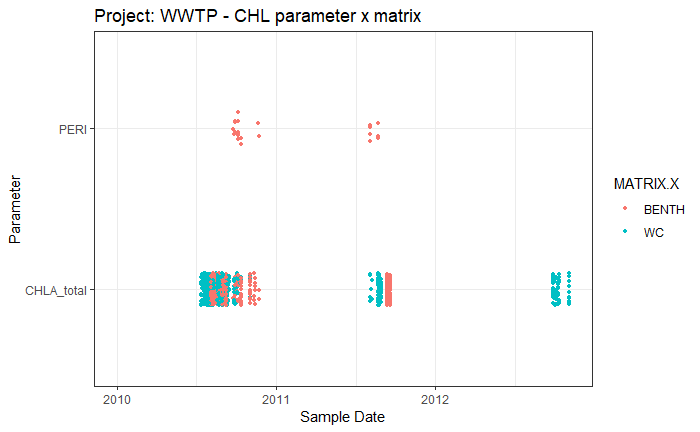

```r
CHL1016_04 %>% filter(PROJ_grp == "WWTP" & PARAM.X != "PHEO" & PARAM.X != "CHLB") %>%
  mutate(PARAM.X = recode(.$PARAM.X,
                          "CHLA.X" = "CHLA_total",
                          "CHLA.tot" = "CHLA_total",
                          "CHLA.aa" = "CHLA_corrected")) %>%
  ggplot(.,
         aes(y=x_SDate, x=factor(PARAM.X),col=MATRIX.X)) + theme_bw() +
  geom_point(na.rm=T,
             position=position_jitter(width=0.1), size=1) +
  xlab("Parameter") + ylab("Sample Date") +
  scale_y_date(date_labels ="%Y",
               date_breaks="1 year",
               limits=c(as.Date("2010-01-01"), NA)) +
  coord_flip() +
  ggtitle("Project: WWTP - CHL parameter x matrix")
```

- Non-Detects

```r
CHL1016_04 %>% filter(PROJ_grp == "WWTP" & PARAM.X != "PHEO" & PARAM.X != "CHLB") %>%
  {addmargins(table(.$PARAM.X, .$Non_Detect, useNA="ifany", deparse.level = 2))}
```

```
          .$Non_Detect
.$PARAM.X     U <NA>  Sum
  CHLA.tot    2    8   10
  CHLA.X    104  930 1034
  PERI        0   23   23
  Sum       106  961 1067
```

- Distribution of reporting limits

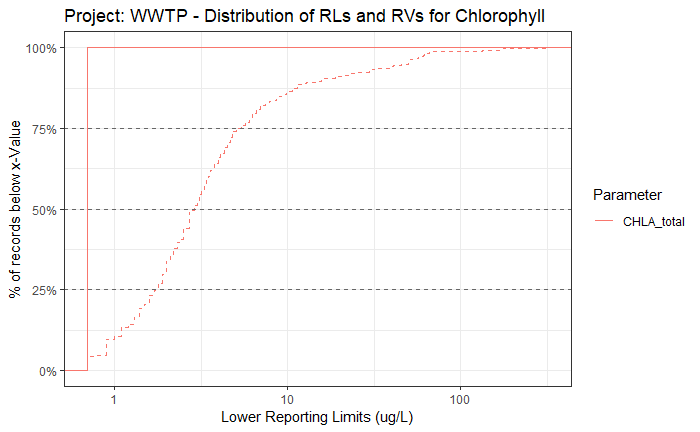

```r
CHL1016_04 %>% filter(PROJ_grp == "WWTP" & PARAM.X != "PHEO" & PARAM.X != "CHLB") %>%
  mutate(PARAM.X = recode(.$PARAM.X,
                          "CHLA.X" = "CHLA_total",
                          "CHLA.tot" = "CHLA_total",
                          "CHLA.aa" = "CHLA_corrected")) %>%
  ggplot(.) + theme_bw() +
  stat_ecdf(aes(x=LRL_c, col=PARAM.X), na.rm=T, lty=1) +
  stat_ecdf(aes(x=x_RVal.conc, col=PARAM.X), na.rm=T, lty=2) +
  labs(x="Lower Reporting Limits (ug/L)", y="% of records below x-Value",
       col="Parameter") +
  scale_x_continuous(trans="log10") +
  scale_y_continuous(labels=percent) +
  geom_hline(yintercept = c(0.25,0.5,0.75), lty=2, color="gray40") +
  ggtitle("Project: WWTP - Distribution of RLs and RVs for Chlorophyll")
```

> **Action**: Do a better accounting of MATRIX.X

### 7.6 Project Prioritization

```r
CHL1016_04 %>% distinct(SKey2, .keep_all = T) %>%
  {addmargins(table(.$PROJ_grp, .$Cost.Code,
                    useNA="ifany"))} %>%
  htmlTable::htmlTable(., css.cell = rbind(rep("padding-left: 0.75em; padding-right: 0.75em;font-size: 0.75em;", times=ncol(.)+1), matrix("padding-left: 0.75em; padding-right: 0.75em; font-size: 0.75em;", ncol=ncol(.)+1, nrow=nrow(.))), caption="", total=T)
```

|  | 301 | 302 | 303 | 304 | 306 | 350 | 351 | 354 | 357 | 358 | 359 | 363 | 375 | 376 | 406 | 552 | 554 | 555 | 854 | Sum |
| --- | --- | --- | --- | --- | --- | --- | --- | --- | --- | --- | --- | --- | --- | --- | --- | --- | --- | --- | --- | --- |
| BOR | 0 | 0 | 0 | 0 | 59 | 3 | 0 | 0 | 0 | 56 | 0 | 0 | 0 | 0 | 0 | 0 | 0 | 0 | 1 | 119 |
| BRI | 69 | 378 | 0 | 0 | 0 | 0 | 0 | 0 | 0 | 0 | 0 | 0 | 0 | 0 | 0 | 0 | 0 | 0 | 0 | 447 |
| CUWJ | 0 | 0 | 0 | 0 | 99 | 12 | 0 | 0 | 0 | 0 | 0 | 0 | 0 | 0 | 20 | 60 | 0 | 0 | 0 | 191 |
| FarmB | 0 | 0 | 0 | 3 | 0 | 0 | 0 | 0 | 0 | 0 | 0 | 0 | 0 | 0 | 0 | 0 | 0 | 0 | 0 | 3 |
| FRNG | 0 | 0 | 0 | 102 | 0 | 0 | 0 | 0 | 0 | 0 | 0 | 0 | 0 | 0 | 0 | 0 | 0 | 0 | 0 | 102 |
| GSLWET | 0 | 0 | 0 | 0 | 0 | 12 | 0 | 0 | 0 | 0 | 0 | 321 | 0 | 0 | 0 | 0 | 0 | 0 | 0 | 333 |
| HAB | 0 | 34 | 0 | 5 | 0 | 0 | 0 | 0 | 0 | 0 | 0 | 0 | 0 | 0 | 0 | 0 | 0 | 0 | 0 | 39 |
| IW | 0 | 0 | 0 | 0 | 0 | 0 | 0 | 0 | 0 | 0 | 0 | 122 | 0 | 0 | 0 | 0 | 0 | 0 | 0 | 122 |
| JRULI | 0 | 0 | 0 | 0 | 0 | 119 | 0 | 0 | 0 | 0 | 766 | 0 | 0 | 0 | 0 | 0 | 0 | 0 | 117 | 1002 |
| LAKES | 0 | 377 | 1 | 0 | 0 | 24 | 194 | 0 | 0 | 0 | 0 | 0 | 0 | 0 | 0 | 0 | 0 | 0 | 14 | 610 |
| NPS | 0 | 0 | 0 | 0 | 1 | 0 | 0 | 0 | 0 | 0 | 0 | 0 | 0 | 0 | 0 | 0 | 0 | 0 | 0 | 1 |
| REFWET | 0 | 0 | 0 | 33 | 0 | 0 | 0 | 0 | 0 | 0 | 0 | 0 | 0 | 0 | 0 | 0 | 0 | 0 | 0 | 33 |
| SBCI | 0 | 62 | 0 | 0 | 0 | 0 | 0 | 0 | 0 | 0 | 0 | 0 | 0 | 0 | 0 | 0 | 0 | 0 | 0 | 62 |
| TMDLLAKES | 0 | 128 | 0 | 0 | 0 | 23 | 6 | 0 | 0 | 0 | 0 | 0 | 0 | 0 | 0 | 0 | 0 | 0 | 250 | 407 |
| UBI | 0 | 0 | 0 | 0 | 0 | 2 | 0 | 0 | 0 | 0 | 0 | 0 | 0 | 0 | 0 | 0 | 0 | 0 | 0 | 2 |
| UCASE | 556 | 3 | 0 | 0 | 0 | 11 | 0 | 0 | 0 | 0 | 0 | 1 | 0 | 0 | 0 | 0 | 0 | 170 | 0 | 741 |
| unknown | 10 | 6 | 0 | 1 | 0 | 0 | 0 | 0 | 0 | 9 | 0 | 0 | 0 | 18 | 0 | 0 | 16 | 0 | 0 | 60 |
| USFS | 0 | 0 | 0 | 0 | 0 | 0 | 0 | 0 | 0 | 47 | 0 | 0 | 0 | 0 | 0 | 0 | 0 | 0 | 0 | 47 |
| UtahLK | 0 | 0 | 5 | 0 | 0 | 1 | 0 | 0 | 0 | 0 | 0 | 0 | 0 | 0 | 0 | 0 | 0 | 0 | 8 | 14 |
| WINTERLAKES | 0 | 0 | 0 | 0 | 0 | 1 | 2 | 0 | 0 | 0 | 0 | 0 | 0 | 0 | 0 | 0 | 0 | 0 | 23 | 26 |
| WLA | 0 | 0 | 0 | 51 | 0 | 0 | 0 | 94 | 0 | 0 | 0 | 0 | 0 | 0 | 0 | 0 | 11 | 0 | 0 | 156 |
| WRI | 0 | 240 | 0 | 0 | 0 | 0 | 0 | 0 | 0 | 0 | 0 | 0 | 0 | 0 | 0 | 0 | 0 | 0 | 0 | 240 |
| WSpur | 0 | 0 | 0 | 8 | 0 | 70 | 0 | 0 | 4 | 0 | 0 | 8 | 948 | 72 | 0 | 0 | 0 | 0 | 0 | 1110 |
| WWTP | 0 | 0 | 0 | 0 | 0 | 183 | 0 | 16 | 0 | 0 | 0 | 0 | 0 | 0 | 0 | 0 | 788 | 0 | 0 | 987 |
| Sum | 635 | 1228 | 6 | 203 | 159 | 461 | 202 | 110 | 4 | 112 | 766 | 452 | 948 | 90 | 20 | 60 | 815 | 170 | 413 | 6854 |

**Projects to Import to AWQMS**

```r
proj_unk
```

```
[1] "HAB"     "unknown" "WWTP"
```

**Remaining Tasks**

1. Cleanup `PROJ_grp` == “unknown”
2. Clarify and cleanup BENTHIC samples
3. Locate last set of volumes…
4. For Non-Detect issues, pay special attention to U-flags from November, 2012 onward. (*Not sure when this practice was corrected, but sometime around the change ot the new LIMS (2017?)*)
5. Re-examine and cleanup duplicated records…

## Next Steps

Have a project prioritization table, see `"chl_project_Priority_table_190829.docx"`, summarizing details about projects (as guidelines)

Also - pay special attention to non-detect records in 2013 and 2014 (starting Nov 2012), where many of these do not seem to be reliable

- Move over to **NEW NOTEBOOK**

## END

```r
CHL1016_03 %>% select(contains("unit", ignore.case = T)) %>% names(.)
```

```r
lastwork.date <- format(Sys.Date(), "%y%m%d")
```

**Start work date ::** 190815  
**Last work date ::** 190822  
**Current review date ::** 190829

eof